# Probabilidad y Estadística Fundamental

Clase 7: Probabilidad condicional

Departamento de Estadı́stica, Sede Bogotá

## Contenido

### Probabilidad condicional

- Definición e interpretación.
- Reducción del espacio muestral.
- Diagramas de Venn.
- Ejemplos de cálculo.

### Reglas y aplicaciones

- Propiedades de la probabilidad condicional.
- Regla de multiplicación.
- Independencia de eventos.
- Ejercicios aplicados.

## Motivación: ¿cambia la probabilidad con información adicional?

- En un sector industrial, se sabe que hay riesgo de **recesion** y de **lluvia excesiva**.
- Sin información adicional, la probabilidad de que ocurra una recesion es del 20%.
- Pero si **ya sabemos que llovió intensamente**, ¿sigue siendo el 20%?
- La **probabilidad condicional** responde exactamente esta pregunta: ¿cómo cambia la probabilidad de un evento cuando ya conocemos que otro ocurrió?
- Este concepto es fundamental para el análisis de datos en agricultura, epidemiología y genética.

## Recordatorio: partición del espacio muestral

Definición (Clase 6)

Una colección de eventos $\{A_1, A_2, \ldots, A_k\}$ forma una **partición** del espacio muestral $\Omega$ si:

- Los eventos son **mutuamente excluyentes**: $A_i \cap A_j = \emptyset$ para todo $i \neq j$.
- Los eventos son **exhaustivos**: $A_1 \cup A_2 \cup \cdots \cup A_k = \Omega$.
- Ejemplo: en un lote de comercio, los tipos de mercado {arcilloso, arenoso, franco} forman una partición del espacio de tipos de mercado.

## Recordatorio: propiedades de la probabilidad

#### Axiomas de Kolmogórov (Clase 6)

- **A1:** $P(A) \geq 0$ para todo evento $A$.
- **A2:** $P(\Omega) = 1$.
- **A3:** Si $A_1, A_2, \ldots$ son mutuamente excluyentes: $P\!\left(\bigcup_{i} A_i\right) = \sum_{i} P(A_i)$.

#### Propiedades derivadas

- $P(A^c) = 1 - P(A)$
- $P(\emptyset) = 0$
- $P(A \cup B) = P(A) + P(B) - P(A \cap B)$
- Si $A \subseteq B$, entonces $P(A) \leq P(B)$.

## Probabilidad condicional: definición

Definición

Sea $B$ un evento con $P(B) > 0$. La **probabilidad condicional** de $A$ dado $B$ se define como:
$$P(A \mid B) = \frac{P(A \cap B)}{P(B)}$$

- Se lee: “probabilidad de $A$ *dado* $B$” o “probabilidad de $A$ *sabiendo que* $B$ ocurrió”.
- La condición $P(B) > 0$ garantiza que la división esté bien definida y sea real.

## Interpretación: reducción del espacio muestral

- Al condicionar en $B$, **reducimos** el espacio muestral de $\Omega$ a $B$.
- Solo nos interesan los resultados que pertenecen a $B$.
- Dentro de ese nuevo espacio, medimos qué proporción corresponde también a $A$, es decir, $A \cap B$.
- **Analógicamente:** si en un incubadora hay 100 empresas en total. De esas, 40 están dentro de un mercado (evento B). Si queremos calcular la probabilidad de que una empresa tenga incumplimientos (evento A) sabiendo que está en el mercado, ya no miramos las 100 empresas, sino solo las 40 que pertenecen a B.
- $$P(A \mid B) = \frac{P(A \cap B)}{P(B)} \quad \text{(espacio equiprobable)}$$

## Interpretación geométrica: diagrama de Venn

Imaginemos el rectángulo $\Omega$ dividido en regiones. El evento $B$ es un óvalo más pequeño dentro de $\Omega$, y $A \cap B$ es la parte donde los dos óvalos se superponen.

Al condicionar en $B$, “recortamos” $\Omega$ al óvalo $B$: ese óvalo se convierte en el nuevo universo de referencia.

$P(A \mid B)$ mide qué fracción del área de $B$ está también cubierta por $A$. Esto equivale al cociente:
$$\dfrac{\text{área}(A \cap B)}{\text{área}(B)}$$

**Clave:** la información reduce el universo de análisis de $\Omega$ a $B$.

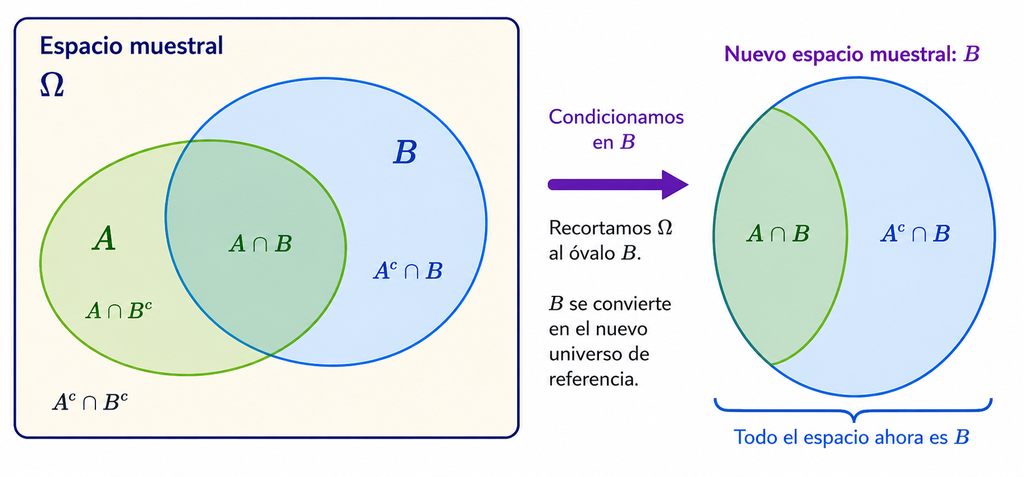

## Ejemplo: lote de 50 empresas comerciales

Se inspeccionan 50 empresas comerciales. Se registra si presentan **incumplimiento** y el **clima** de la zona.

|  | Con incumplimiento | Sin incumplimiento | Total |
| --- | --- | --- | --- |
| Clima cálido | 18 | 12 | **30** |
| Clima frío | 6 | 14 | **20** |
| Total | 24 | 26 | 50 |

- Definamos: $A$ = La empresa tiene incumplimiento y $B$ = La empresa está en clima cálido.
- $P(A) = \dfrac{24}{50} = 0.48$; $\quad P(B) = \dfrac{30}{50} = 0.60$; $\quad P(A \cap B) = \dfrac{18}{50} = 0.36$.

## Cálculo $P(\text{incumplimiento} \mid \text{clima cálido})$

#### Aplicando la definición

- $$P(\text{incumplimiento} \mid \text{cálido}) = \frac{P(A \cap B)}{P(B)}$$
- Reemplazando las probabilidades:
- $$\frac{P(A \cap B)}{P(B)}= \frac{18/50}{30/50} = \frac{18}{30} = 0.60$$

#### Interpretación

- Entre las empresas de clima cálido, el **60%** tiene incumplimiento.
- Sin la información del clima, la probabilidad de incumplimiento era solo el 48%.
- El clima cálido **incrementa** la probabilidad de presencia de incumplimiento.

## Cálculo $P(\text{clima frío} \mid \text{sin incumplimiento})$

Definamos: $C$ = La empresa no tiene incumplimiento y $D$ = La empresa está en clima frío.Sus respectivas probabilidades son:

$P(C)=\dfrac{26}{50}=0.52; \quad P(D)=\dfrac{20}{50}=0.40; \quad P(C \cap D)=\dfrac{14}{50}=0.28$.

$$\frac{P(C \cap D)}{P(C)}= \frac{14/50}{26/50} = \frac{14}{26} \approx 0.538$$

#### Interpretación

- Entre las empresas sin incumplimiento, aproximadamente el **53.8%** proviene de clima frío.
- El clima frío está asociado con menor presencia de incumplimientos.

## Propiedades de la probabilidad condicional

Dado $B$ con $P(B)>0$, la función $P(A \mid B)$ satisface los mismos axiomas de Kolmogórov:

- $P(A \mid B) \geq 0$ para todo evento $A$.
- $P(\Omega \mid B) = 1$, ya que $P(\Omega \cap B)=P(B)$ y $P(B \mid B) = 1$.
- Si $A_1, A_2, \ldots$ son mutuamente excluyentes: $P\!\left(\bigcup_i^\infty A_i \mid B\right) = \sum_i^\infty P(A_i \mid B)$.
- $P(A^c \mid B) = 1 - P(A \mid B)$.
- $P(A \cup C \mid B) = P(A\mid B) + P(C\mid B) - P(A \cap C \mid B)$.

## Ejemplo con dados: $P(\text{par} \mid \text{mayor que } 3)$

#### Planteamiento

- Se lanza un dado equilibrado. $\Omega = \{1,2,3,4,5,6\}$.
- Sea: $A$ : resultado par $= \{2,4,6\}$.
- $B$ : resultado mayor que 3 $= \{4,5,6\}$.
- $A \cap B = \{4,6\}$.

#### Cálculo

- $$P(A \mid B) = \frac{P(A \cap B)}{P(B)} = \frac{2/6}{3/6} = \frac{2}{3}$$
- Saber que el resultado es mayor que 3 aumenta la probabilidad de par de $1/2$ a $2/3$.

## Ejercicio: sector servicios

Se inspeccionan 60 empresas de servicios. Se registra la **estrategia** (A o B) y la **calidad del producto** (alta o baja).

|  | Calidad alta | Calidad baja | Total |
| --- | --- | --- | --- |
| Estrategia A | 20 | 10 | **30** |
| Estrategia B | 12 | 18 | **30** |
| Total | 32 | 28 | 60 |

Calcule:

1. $P(\text{calidad alta} \mid \text{estrategia A})$
2. $P(\text{estrategia B} \mid \text{calidad baja})$.

## Solución punto 1

#### $P(\text{calidad alta} \mid \text{estrategia A})$

- $P(\text{calidad alta} \cap \text{estrategia A}) = \dfrac{20}{60}$
- $P(\text{var A}) = \dfrac{30}{60}$
- $$P(\text{calidad alta} \mid \text{var A}) = \frac{20/60}{30/60} = \frac{20}{30} \approx 0.667$$

#### Interpretación

- El **66.7%** de las empresas de estrategia A producen producto de calidad alta.
- Sin condicionamiento, $P(\text{calidad alta}) = 32/60 \approx 0.533$.

## Solución punto 2

#### $P(\text{estrategia B} \mid \text{calidad baja})$

- $P(\text{var B} \cap \text{calidad baja}) = \dfrac{18}{60}$
- $P(\text{calidad baja}) = \dfrac{28}{60}$
- $$P(\text{var B} \mid \text{calidad baja}) = \frac{18/60}{28/60} = \frac{18}{28} \approx 0.643$$

#### Interpretación

- El **64.3%** de los productos de baja calidad provienen de la estrategia B.
- La estrategia B está más asociada con baja calidad que la estrategia A.

## $P(A \mid B)$ vs $P(B \mid A)$ no son iguales

#### Error frecuente

- En general: $P(A \mid B) \neq P(B \mid A)$.
- En el ejemplo del comercio: $P(\text{incumplimiento} \mid \text{cálido}) = 0.60$
- Pero $P(\text{cálido} \mid \text{incumplimiento}) = \dfrac{18}{24} = 0.75$.

#### Regla de simetría

- La relación entre ambas es precisamente el **Teorema de Bayes**:
  $$P(B \mid A) = \frac{P(A \mid B) \cdot P(B)}{P(A)}$$
- Este teorema será el tema central de la **Clase 8**.

## Regla de la multiplicación: derivación

Regla de la multiplicación

Despejando $P(A \cap B)$ de la definición de probabilidad condicional:
$$P(A \cap B) = P(A \mid B) \cdot P(B) = P(B \mid A) \cdot P(A)$$

- Permite calcular la probabilidad de que **dos eventos ocurran juntos**.
- Es válida siempre que $P(B) > 0$ o $P(A) > 0$ respectivamente.

## Extensión a tres eventos

Para tres eventos $A$, $B$, $C$

$$P(A \cap B \cap C) = P(A \mid B \cap C) \cdot P(B \mid C) \cdot P(C)$$

- En general, para $n$ eventos:
  $$P(A_1 \cap A_2 \cap \cdots \cap A_n) = P(A_1) \cdot P(A_2 \mid A_1) \cdot P(A_3 \mid A_1 \cap A_2) \cdots$$
- Esta regla es especialmente útil cuando los eventos ocurren en **etapas secuenciales**.

## Ejemplo: seleccionar 2 empresas sin reposición

#### Planteamiento

- Un lote tiene 10 empresas de cartera: 7 sanas y 3 con enfermedad.
- Se seleccionan 2 empresas al azar **sin reposición**.
- Sean los eventos: $A$ = 1ª empresa sana y $B$ = 2ª empresa sana.

#### Cálculo

- $P(A) = \dfrac{7}{10}$
- $P(B \mid A) = \dfrac{6}{9}$ (quedan 6 sanas de 9)
- $$P(A \cap B) = P(A) \cdot P(B \mid A) = \frac{7}{10} \times \frac{6}{9} = \frac{42}{90} \approx 0.467$$

## Ejemplo: 3 etapas de control de calidad en cartera

Un empresa de cartera pasa por 3 etapas de control: fumigación ($F$), financiación controlado ($R$) y poda sanitaria ($P$).  
Calcular la probabilidad de que cada etapa se aplique correctamente depende de las anteriores.

- Se tienen las siguientes probabilidades:
- $P(F) = 0.90$ (Probabilidad de la fumigación)
- $P(R \mid F) = 0.85$ (Probabilidad de la financiación dado que la fumigación fue correcta)
- $P(P \mid F \cap R) = 0.80$ (Probabilidad de la poda dado que las etapas anteriores fueron correctas)
- $$P(F \cap R \cap P) = P(F) \times P(R \mid F) \times P(P \mid F \cap R) = 0.90 \times 0.85 \times 0.80 = 0.612$$
- Hay un **61.2%** de probabilidad de que las 3 etapas se apliquen correctamente.

## Ejercicio: selección de proyectos en 2 pasos

- Una caja contiene 8 proyectos comerciales:
- 5 de alta éxito (AG)
- 3 de baja éxito (BG)
- Se seleccionan 2 proyectos sin reposición. Calcule la probabilidad de que:
- 1. Ambas proyectos sean de alta éxito.
- 2. La primera sea AG y la segunda BG.
- 3. Al menos una sea AG.

#### Solución

- **a.** $P(\text{AG}_1 \cap \text{AG}_2) = \dfrac{5}{8} \times \dfrac{4}{7} = \dfrac{20}{56} \approx 0.357$
- **b.** $P(\text{AG}_1 \cap \text{BG}_2) = \dfrac{5}{8} \times \dfrac{3}{7} = \dfrac{15}{56} \approx 0.268$
- **c.** $P(AG\geq 1) = 1 - P(\text{BG}_1 \cap \text{BG}_2)\\ = 1 - \dfrac{3}{8} \times \dfrac{2}{7}\\ = 1 - \dfrac{6}{56} = \dfrac{50}{56} \approx 0.893$

## Independencia de eventos: definición

Definición

Dos eventos $A$ y $B$ son **estadísticamente independientes** si y solo si:
$$P(A \cap B) = P(A) \cdot P(B)$$

- La ocurrencia de uno **no afecta** la probabilidad del otro.
- Esta definición no requiere que $P(A) > 0$ ni $P(B) > 0$.

## Equivalencias de la independencia

Si $A$ y $B$ son independientes y $P(B) > 0$, entonces:

- $P(A \mid B) = P(A)$ conocer $B$ no cambia la probabilidad de $A$.
- $P(B \mid A) = P(B)$ conocer $A$ no cambia la probabilidad de $B$.
- $A$ y $A^c$ son independientes de $B$ (y de $B^c$).
- Las tres condiciones son equivalentes y pueden usarse indistintamente para **verificar independencia**.

## Independencia NO implica disjunción

#### Aclaración importante

- Dos eventos **disjuntos** ($A \cap B = \emptyset$) con $P(A)>0$ y $P(B)>0$ son **dependientes**, no independientes.
- Si $A$ ocurre, sabemos que $B$ no puede ocurrir, por lo que $P(B \mid A) = 0 \neq P(B)$.

#### Resumen

|  | $A \cap B = \emptyset$ | $A \cap B \neq \emptyset$ |
| --- | --- | --- |
| **Independientes** | No (salvo $P=0$) | Posible |
| **Dependientes** | Sí | Posible |

## Ejemplo: lluvia en dos empresas distantes

#### Planteamiento

Se tienen dos empresas que están a 700 km de distancia: Empresa 1 (Huila) y Empresa 2 (Cesar).

- $P(\text{lluvia en F1}) = 0.30$ $P(\text{lluvia en F2}) = 0.40$
- $P(\text{lluvia en F1 y F2}) = 0.12$

#### Verificación

- $P(F_1) \cdot P(F_2) = 0.30 \times 0.40 = 0.12$
- $P(F_1 \cap F_2) = 0.12$ ✓
- Conclusión: los eventos son **independientes**. La lluvia en una empresa no influye en la otra.

## Ejemplo: incumplimientos en empresas de clima cálido vs frío

En el ejemplo del comercio (lote de 50 empresas), verifiquemos si **incumplimiento** y **clima cálido** son independientes.

- $P(\text{incumplimiento}) = 24/50 = 0.48$
- $P(\text{clima cálido}) = 30/50 = 0.60$
- $P(\text{incumplimiento}) \cdot P(\text{clima cálido}) = 0.48 \times 0.60 = 0.288$
- $P(\text{incumplimiento} \cap \text{clima cálido}) = 18/50 = 0.360$
- Como $0.360 \neq 0.288$, los eventos **no son independientes**: el clima cálido está asociado con mayor presencia de incumplimiento.

## Independencia mutua de $n$ eventos

Definición

Los eventos $A_1, A_2, \ldots, A_n$ son **mutuamente independientes** si para todo subconjunto $\{i_1, i_2, \ldots, i_k\} \subseteq \{1,\ldots,n\}$:
$$P(A_{i_1} \cap A_{i_2} \cap \cdots \cap A_{i_k}) = P(A_{i_1}) \cdot P(A_{i_2}) \cdots P(A_{i_k})$$

- Para $n$ eventos se requieren $2^n - n - 1$ condiciones en total.
- La independencia mutua implica independencia por pares, pero **no al revés**.

## Independencia a pares vs independencia mutua

#### Independencia a pares

- $P(A_i \cap A_j) = P(A_i) \cdot P(A_j)$ para todo $i \neq j$.
- No garantiza que los tres eventos sean mutuamente independientes.

#### Independencia mutua

- Requiere además que: $P(A_1 \cap A_2 \cap A_3) = P(A_1) \cdot P(A_2) \cdot P(A_3)$
- Es la condición más fuerte y la que se usa en la práctica para procesos secuenciales.

## Ejemplo: 3 condiciones de mercado en mercado

En un mercado de comercio minorista, tres sistemas funcionan de forma independiente: ventilación ($V$), financiación ($R$) y control de temperatura ($T$).  
Sus probabilidades de fallo en un día son: $P(V) = 0.05$, $P(R) = 0.03$, $P(T) = 0.02$.

Calcular las siguientes probabilidades:

- $P(\text{los 3 fallan}) = P(V) \cdot P(R) \cdot P(T) = 0.05 \times 0.03 \times 0.02 = 0.00003$
- $P(\text{ninguno falla}) = (1-0.05)(1-0.03)(1-0.02) = 0.95 \times 0.97 \times 0.98 \approx 0.903$
- $P(\text{al menos uno falla}) = 1 - 0.903 = 0.097$

## Ejercicio: éxito de proyectos de inversión

- Se siembran 4 proyectos de inversión de forma independiente. La probabilidad de éxito de cada proyecto es $p = 0.75$.
- Calcule la probabilidad de que **al menos un proyecto tenga éxito**.
- Calcule también la probabilidad de que **exactamente 3 tengan éxito**.

#### Al menos una tiene éxito

- $P(\text{ninguna}) = (0.25)^4 = 0.0039$ (ninguna tiene éxito, todas fallan)
- $P(\geq 1) = 1 - 0.0039 = \mathbf{0.9961}$ (la probabilidad de que al menos una tenga éxito es el complemento de que ninguna tenga éxito)

#### Exactamente 3 tienen éxito

- Sea el caso específico: las primeras 3 tienen éxito y la última no. La probabilidad de este caso es:
- $P(\text{un proyecto no tiene éxito}) = (0.75)^3 \times (0.25) = 0.1055$
- Pero hay 4 formas de elegir cuál proyecto no tiene éxito, por lo que:  
  $P(\text{exactamente 3}) = 4 \times 0.1055 = \mathbf{0.422}$
- Hay un 42.2% de probabilidad de que exactamente 3 de las 4 proyectos tengan éxito.

## Ley de la probabilidad total

- A veces **no conocemos directamente** $P(A)$.
- Sin embargo, sí conocemos $P(A \mid B_i)$ para cada elemento de una partición $\{B_1, \ldots, B_k\}$.
- Ejemplo: queremos saber $P(\text{incumplimiento en empresas})$, pero solo conocemos la probabilidad de enfermedad según el **tipo de mercado**.
- La ley de probabilidad total nos permite **combinar** estas probabilidades condicionales.

## Partición del espacio muestral (recordatorio)

Partición $\{B_1, B_2, \ldots, B_k\}$

Los $B_i$ son mutuamente excluyentes ($B_i \cap B_j = \emptyset$, $i \neq j$) y exhaustivos ($\bigcup_{i=1}^k B_i = \Omega$).

Todo evento $A$ se puede descomponer como:
$$A = (A \cap B_1) \cup (A \cap B_2) \cup \cdots \cup (A \cap B_k)$$
donde los conjuntos $(A \cap B_i)$ son **disjuntos entre sí**.

## Ley de la probabilidad total: enunciado

Teorema

Si $\{B_1, B_2, \ldots, B_k\}$ es una partición de $\Omega$ y $P(B_i) > 0$ para todo $i$, entonces para cualquier evento $A$:
$$P(A) = \sum_{i=1}^{k} P(A \mid B_i) \cdot P(B_i)$$

- La probabilidad total de $A$ es el **promedio ponderado** de las probabilidades condicionales, con pesos $P(B_i)$.

## Demostración de la ley de probabilidad total

- Como $\{B_i\}$ es partición: $A = \bigcup_{i=1}^k (A \cap B_i)$ con $(A \cap B_i)$ disjuntos.
- Por aditividad (Axioma A3):
  $$P(A) = \sum_{i=1}^k P(A \cap B_i)$$
- Por la regla de la multiplicación: $P(A \cap B_i) = P(A \mid B_i) \cdot P(B_i)$.
- Sustituyendo:
  $$P(A) = \sum_{i=1}^k P(A \mid B_i) \cdot P(B_i) \qquad \blacksquare$$

## Ejemplo 1: tipo de mercado y incumplimiento en empresas

En un mercado de productos (clima cálido), el tipo de mercado se clasifica en arcilloso, arenoso y franco. La presencia de enfermedad varía según el tipo de mercado.

| **Tipo de mercado** | **$P(B_i)$** | **$P(\text{enf} \mid B_i)$** |
| --- | --- | --- |
| Arcilloso ($B_1$) | 0.40 | 0.30 |
| Arenoso ($B_2$) | 0.35 | 0.15 |
| Franco ($B_3$) | 0.25 | 0.10 |

- ¿Cuál es la probabilidad de que una empresa elegida al azar tenga enfermedad?

## Cálculo $P(\text{enfermedad})$ con la ley de probabilidad total

#### Aplicando la fórmula

- $P(E) = P(E \mid B_1) \cdot P(B_1)\\+ P(E \mid B_2) \cdot P(B_2)\\ + P(E \mid B_3) \cdot P(B_3)$
- Reemplazando las probabilidades:
- $P(E)= 0.30 \times 0.40 + 0.15 \times 0.35 + 0.10 \times 0.25$
- $= 0.120 + 0.0525 + 0.025 = \mathbf{0.1975}$
- Por lo tanto la probabilidad de enfermedad en el empresa es: $P(E) = \mathbf{0.1975}$

#### Interpretación

- El **19.75%** de las empresas de productos presentan enfermedad, considerando la distribución de tipos de mercado.
- El mercado arcilloso contribuye más a la enfermedad por su mayor prevalencia y mayor probabilidad condicional.

## Ejemplo 2: proveedores de proyectos industriales

- Una empresa compra proyectos industriales de 3 proveedores: Proveedor A (50%), B (30%) y C (20%). La probabilidad de que un proyecto sea defectuosa es 0.02, 0.05 y 0.08 respectivamente.
- Aplicando la fórmula de la ley de probabilidad total.
- $P(\text{defect}) = P(D \mid A) \cdot P(A) + P(D \mid B) \cdot P(B) + P(D \mid C) \cdot P(C)$
- Reemplazando:
- $P(\text{defect.})= 0.02 \times 0.50 + 0.05 \times 0.30 + 0.08 \times 0.20= 0.010 + 0.015 + 0.016 = \mathbf{0.041}$
- El **4.1%** de los proyectos son defectuosas.

## Ejercicio: zonas climáticas y rentabilidad de cartera

- Un gestor administra cartera en tres zonas climáticas con las siguientes proporciones y probabilidades de rentabilidad alta:

| **Zona** | **$P(Z_i)$** | **$P(\text{rentabilidad alta} \mid Z_i)$** |
| --- | --- | --- |
| Zona fría alta ($Z_1$) | 0.50 | 0.70 |
| Zona fría media ($Z_2$) | 0.30 | 0.55 |
| Zona templada ($Z_3$) | 0.20 | 0.35 |

- Calcule $P(\text{rentabilidad alta})$ usando la ley de probabilidad total.

## Ejercicio: sector minorista

- En un lote de 80 empresas de comercio minorista, se registra la presencia de **incumplimiento** y si recibieron **tratamiento preventivo**:

|  | **Con incumplimiento** | **Sin incumplimiento** | **Total** |
| --- | --- | --- | --- |
| **Con tratamiento** | 8 | 32 | 40 |
| **Sin tratamiento** | 22 | 18 | 40 |
| **Total** | 30 | 50 | 80 |

- Calcule las siguientes probabilidades:
- 1. $P(\text{incumplimiento} \mid \text{con tratamiento})$ 2. $P(\text{incumplimiento} \mid \text{sin tratamiento})$
- 3. $P(\text{con tratamiento} \mid \text{incumplimiento})$ 4. $P(\text{sin tratamiento} \mid \text{sin incumplimiento})$

## Solución parte 1

#### Probabilidades condicionadas al tratamiento

- 1. $P(\text{incumplimiento} \mid \text{con tratamiento}) = \dfrac{8}{40} = 0.20$
- 2. $P(\text{incumplimiento} \mid \text{sin tratamiento}) = \dfrac{22}{40} = 0.55$
- El tratamiento **reduce el riesgo** de incumplimiento de 55% a 20%.

#### Verificación de independencia

- $P(\text{incumplimiento}) = 30/80 = 0.375$
- $P(\text{incumplimiento} \mid \text{con tratamiento}) = 0.20 \neq 0.375$
- Los eventos **no son independientes**. Hay dependencia entre tratamiento y presencia de incumplimiento.

## Solución parte 2

#### Condicionadas al resultado de salud

- 3. $P(\text{con tratamiento} \mid \text{incumplimiento}) = \dfrac{8}{30} \approx 0.267$
- 4. $P(\text{sin tratamiento} \mid \text{sin incumplimiento}) = \dfrac{18}{50} = 0.36$

#### Conclusión

- De las empresas con incumplimiento, solo el 26.7% había recibido tratamiento preventivo.
- El tratamiento es efectivo para reducir la aparición de incumplimientos en las tiendas.

## Ejercicio: éxito en dos etapas

Se realiza un proceso de éxito en dos etapas para proyectos de cartera. En la primera etapa, el 70% de los proyectos pasa a la segunda. De las que pasan, el 80% tiene éxito exitosamente. De las que no pasan la primera etapa, el 20% igual logra tener éxito.

- Sean los eventos: $E_1$ = pasa primera etapa y $G$ = tiene éxito.
- $P(E_1) = 0.70$, por lo tanto $P(E_1^c) = 0.30$
- $P(G \mid E_1) = 0.80$, por lo tanto $P(G \mid E_1^c) = 0.20$
- ¿Cuál es la probabilidad de que un proyecto tenga éxito?

## Solución

#### Utilizando la ley de probabilidad total:

- $P(G) = P(G \mid E_1)P(E_1) + P(G \mid E_1^c)P(E_1^c)$
- Reemplazando:
- $P(G) = 0.80 \times 0.70 + 0.20 \times 0.30=0.560 + 0.060 = \mathbf{0.620}$

#### Resultado

- $P(G) = 0.620$
- El **62%** de los proyectos de cartera tiene éxito exitosamente en este proceso de dos etapas.

## Ejercicio: independencia en políticas

En un experimento con cartera de inversiones, se aplican dos políticas de forma independiente: política $X$ con efectividad del 85% y política $Y$ con efectividad del 70%. Se dice que la incumplimiento es controlada si al menos uno de los dos políticas es efectivo.

- Sean  
  $X$ = El política X es efectivo.  
  $Y$ = El política Y es efectivo.
- $P(X) = 0.85$, $P(Y) = 0.70$, $X$ e $Y$ son independientes.
- ¿Cuál es la probabilidad de que la incumplimiento sea controlada?

## Solución

#### Usando el complemento

- $P(\text{ninguno efectivo}) = P(X^c) \cdot P(Y^c)$ (por independencia)
- $P(\text{ninguno efectivo})= 0.15 \times 0.30 = 0.045$
- Por lo tanto, la probabilidad de que la incumplimiento sea controlada es:
- $P(\text{controlada}) = 1 - 0.045 = \mathbf{0.955}$

#### Verificación directa

- $P(X \cup Y)$ (Probabilidad de que al menos uno sea efectivo)
- $P(X \cup Y) = P(X) + P(Y) - P(X \cap Y)$
- $P(X \cup Y)= 0.85 + 0.70 - (0.85 \times 0.70)$
- $= 1.55 - 0.595 = \mathbf{0.955}$ ✓
- Resolviendo por ambos métodos se obtiene el mismo resultado: $P(\text{controlada}) = 0.955$.

## Errores comunes en probabilidad condicional

- **Error 1:** Confundir $P(A \mid B)$ con $P(B \mid A)$ (estos resultados son distintos en general).
- **Error 2:** Asumir independencia sin verificarla (siempre comprobar $P(A \cap B) = P(A) \cdot P(B)$).
- **Error 3:** Confundir eventos disjuntos con eventos independientes (son conceptos opuestos).
- **Error 4:** Olvidar que $P(B) > 0$ (es requisito para calcular $P(A \mid B)$).
- **Error 5:** No usar el complemento para simplificar cálculos de “al menos uno”.

## Aplicaciones en investigación económico

#### Epidemiología vegetal

- $P(\text{enfermedad} \mid \text{vector})$ para modelar propagación de incumplimientos en empresas de cartera y productos.
- Identificar factores de riesgo condicionados al clima.

#### Mejoramiento genético

- $P(\text{alto rentabilidad} \mid \text{genotipo})$ para seleccionar estrategias de la industria, comercio minorista y inversiones.
- Ley de probabilidad total para combinar efectos de múltiples factores.

## Tabla resumen: fórmulas clave de la clase

| **Concepto** | **Fórmula** |
| --- | --- |
| Prob. condicional | $P(A \mid B) = \dfrac{P(A \cap B)}{P(B)}$ |
| Regla de multiplicación | $P(A \cap B) = P(A \mid B) \cdot P(B)$ |
| Independencia | $P(A \cap B) = P(A) \cdot P(B)$ |
| Prob. total | $P(A) = \sum_i P(A \mid B_i) \cdot P(B_i)$ |

- Todas las fórmulas se derivan de los axiomas de Kolmogórov estudiados en la Clase 6.

## Mapa conceptual de relaciones entre conceptos

Probabilidad $P(A)$

↓

Información nueva $B$

↓

Prob. condicional $P(A \mid B)$

Regla de multiplicación

Independencia

Ley prob. total

Teorema de Bayes (Clase 8)

## Verificación: ¿cuándo usar cada herramienta?

#### Probabilidad condicional

- Cuando conocemos que un evento $B$ ya ocurrió y queremos actualizar la probabilidad de $A$.

#### Regla de multiplicación

- Cuando necesitamos calcular $P(A \cap B)$ y conocemos probabilidades condicionales.

#### Independencia

- Cuando el contexto sugiere que los eventos no se influyen (distancia geográfica, procesos separados).

#### Ley de probabilidad total

- Cuando se conoce $P(A \mid B_i)$ para cada elemento de una partición y se quiere $P(A)$.

## Ejercicio: verdadero o falso

- **1.** Si $A$ y $B$ son mutuamente excluyentes, entonces son independientes. **FALSO**
- **2.** $P(A \mid B) + P(A^c \mid B) = 1$. **VERDADERO**
- **3.** Si $P(A \mid B) = P(A)$, entonces $P(B \mid A) = P(B)$. **VERDADERO**
- **4.** La ley de probabilidad total requiere que los $B_i$ sean equiprobables. **FALSO**

## Resumen

**Prob. Condicional**  
$P(A \mid B) = \dfrac{P(A \cap B)}{P(B)}$  
*Reduce el espacio muestral*

**Regla Multiplicación**  
$P(A \cap B) = P(A\mid B)\cdot P(B)$  
*Eventos secuenciales*

**Independencia**  
$P(A \cap B) = P(A)\cdot P(B)$  
*Sin influencia mutua*

**Prob. Total**  
$P(A) = \sum_i P(A\mid B_i)P(B_i)$  
*Combinar particiones*

## Ejercicio adicional: ley de probabilidad total en cartera de crédito

#### Enunciado

- Los créditos provienen de 3 zonas: Z1 (clima frío alto, 50%), Z2 (clima frío medio, 30%) y Z3 (clima templado, 20%)  
  La probabilidad de que una cartera tenga incumplimientos dado la zona es:  
  $P(H|Z1)=0.05$; $P(H|Z2)=0.10$; $P(H|Z3)=0.15$.  
  Hallar $P(H)$

#### Solución

- $P(H) = P(H|Z1)P(Z1) + P(H|Z2)P(Z2) + P(H|Z3)P(Z3)$
- $P(H)= 0.05(0.50) + 0.10(0.30) + 0.15(0.20)= 0.025 + 0.030 + 0.030 = 0.085$
- $P(H) = 0.085$
- El 8.5% de los créditos tiene incumplimientos, considerando la distribución de zonas y sus riesgos asociados.

## Tabla resumen: fórmulas clave de la clase

| Concepto | Fórmula | Condición |
| --- | --- | --- |
| Probabilidad condicional | $P(A\|B) = \frac{P(A \cap B)}{P(B)}$ | $P(B)>0$ |
| Regla de multiplicación | $P(A \cap B) = P(A\|B)P(B)$ | , |
| Independencia | $P(A \cap B) = P(A)P(B)$ | , |
| Prob. total | $P(A) = \sum_i P(A\|B_i)P(B_i)$ | $\{B_i\}$ partición |

## Ejercicios de práctica

Ejercicio 1: Prob. Condicional

En un lote de 60 empresas comerciales, 36 recibieron inversión y 24 no. De las financiadas, 27 tienen buen rentabilidad; de las no financiadas, 6 tienen buen rentabilidad. Si se elige una empresa al azar y tiene buen rentabilidad, ¿cuál es la probabilidad de que haya recibido inversión?

Ejercicio 2: Regla de Multiplicación

En un proceso de ventas de industria, primero se clasifica el producto (80% pasa la clasificación) y luego se lava (de los que pasan, el 90% queda apto para venta). Calcule la probabilidad de que un producto quede clasificado **y** apto para venta.

Ejercicio 3: Independencia

En un mercado de comercio minorista, la probabilidad de que fallen el sistema de financiación y el sistema de iluminación es 0.06. La probabilidad de fallo de la financiación es 0.20 y la de la iluminación es 0.30. ¿Son independientes los fallos de los dos sistemas? Justifique.

Ejercicio 4: Prob. Total

Un mercado de productos se distribuye en tres regiones: Llanos (40%), Andina (35%) y Caribe (25%). La probabilidad de ataque de incumplimiento es 0.25, 0.15 y 0.35 respectivamente. ¿Cuál es la probabilidad de que una empresa elegida al azar esté atacada por incumplimiento?

¡Gracias!

Clase 7, Probabilidad condicional e independencia

Probabilidad y Estadística Fundamental · Universidad Nacional de Colombia

Próxima clase: **Teorema de Bayes**